# Udacity CARND — Unscented Kalman Filter Project

This notebook contains code to process and evaluate the NIS values collected from different test runs of the project.

The NIS data for radar and lidar have been collected in distinct sessions (only the measurements of one sensors type wered used in a single run).

```python
import os.path
import numpy as np
import matplotlib.pyplot as plt
```

```python
def plot_nis_values(std_a, std_yawd, data_dir='./data', file_suffix=''):
    """
    Plotting a simple chart from the NIS values found in the data files specified by `std_a` and `std_yawd`.
    We expect the following file naming convention:

        <data_dir>/<Lidar|Radar>_NIS_values_<std_a>_<std_yawd><optional file suffix>.txt

    """

    chi_squared_95_limits = {'Lidar': 5.991, 'Radar': 7.815}

    fig, axes = plt.subplots(2,1, figsize=(20,16))
    axes = axes.ravel()

    for i, target in enumerate(chi_squared_95_limits):

        # assembling filename
        filename = data_dir + '/' + target + '_NIS_values_' + str(std_a) + '_' + str(std_yawd) + file_suffix + '.txt'

        if os.path.exists(filename):

            # reading in the file
            values = [float(line) for line in open(filename)]
            message = "{} -- read {} lines from file".format(filename, len(values))

            # fetching the predefined limit belonging to the given sensor type
            limit = chi_squared_95_limits[target]

            # fake list to plot (=this will be a line)
            limit_values = [limit for _ in values]

            # preparing the X axis
            t = np.arange(0, len(values))

            # calculating statistics
            under_limit = [1 if x <= limit else 0 for x in values]
            under_limit_percent = round(100 * sum(under_limit) / len(values), 2)

            # plotting the data
            axes[i].plot(t, values)
            axes[i].plot(t, limit_values, 'r')

            axes[i].set_xlabel('Time step', fontsize=16)
            axes[i].set_ylabel(target + ' NIS values', fontsize=16)

            # other nuances
            axes[i].grid(True)
            axes[i].legend([target + ' NIS', '95%'], fontsize=20)

            # some nice info text as title
            title = "The {} NIS values are in {}% of the cases under {}".format(target.lower(), under_limit_percent, limit)

        else:
            # we're deeply sorry
            title = "{} NIS values are unavailable".format(target)
            message = "{} -- file does not exist.".format(filename)
            axes[i].set_facecolor('xkcd:salmon')

        # setting title in any case
        axes[i].set_title(title, fontsize=20)

        # printing some debug info
        print(message)
```

Let's try out the values that are there by default. Unfortunately I couldn't make the simulator to run all the way through using the radar measurements only.

```
./data/Lidar_NIS_values_30.0_30.0.txt -- read 249 lines from file
./data/Radar_NIS_values_30.0_30.0.txt -- file does not exist.
```

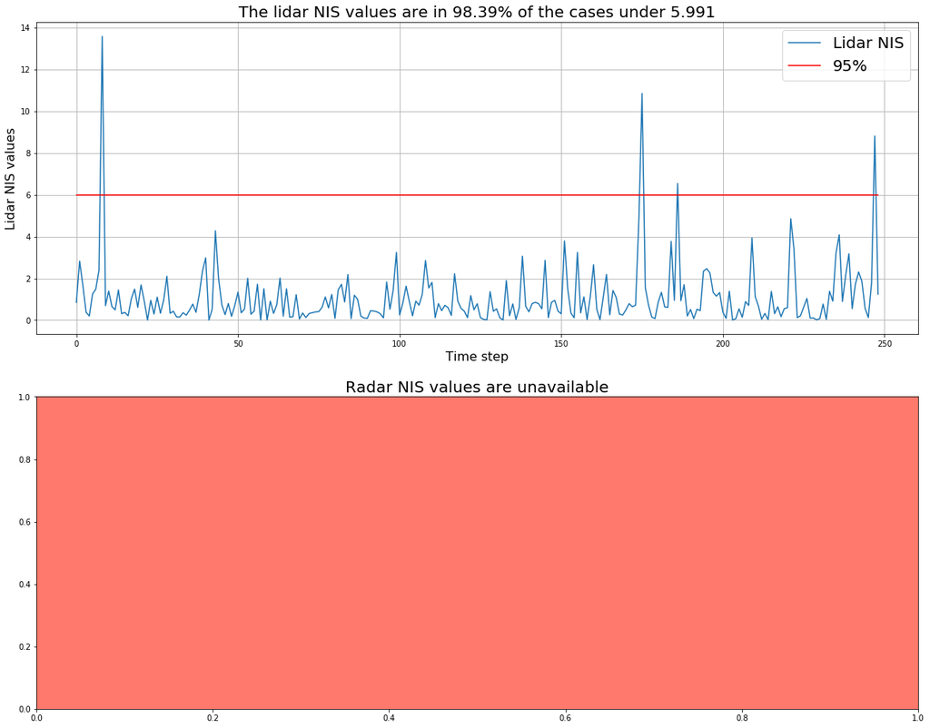

```python
plot_nis_values(30.0, 30.0)
```

...but it definitely looks too high, the noise parameter values have to be decreased. Okay, let's try out values that are significantly smaller.

```
./data/Lidar_NIS_values_1.0_0.1.txt -- read 249 lines from file
./data/Radar_NIS_values_1.0_0.1.txt -- read 249 lines from file
```

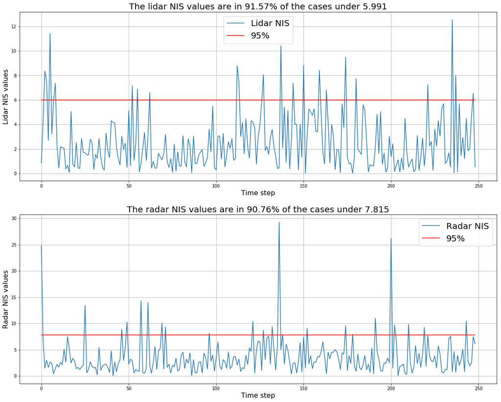

```python
plot_nis_values(1.0, 0.1)
```

These values are apparently too small — they have to be increased. Let's start the iteration!

```
./data/Lidar_NIS_values_6.0_0.6.txt -- read 249 lines from file
./data/Radar_NIS_values_6.0_0.6.txt -- read 249 lines from file
```

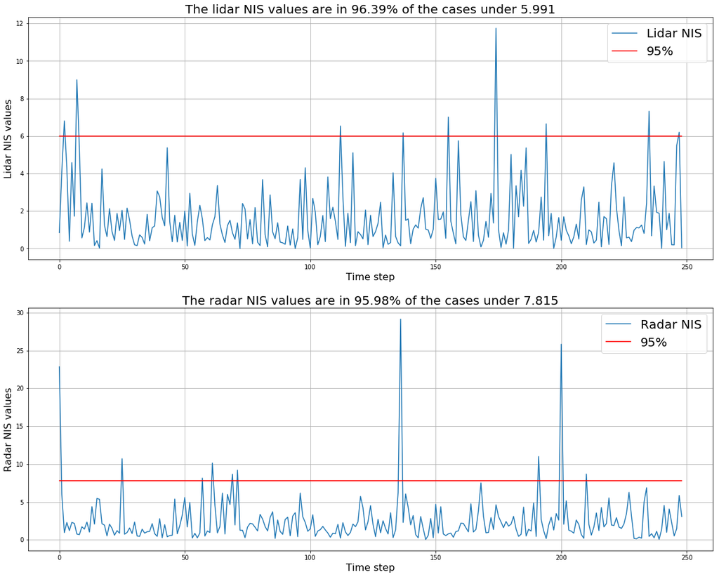

```python
plot_nis_values(6.0, 0.6)
```

Still too high.

```
./data/Lidar_NIS_values_3.0_0.3.txt -- read 249 lines from file
./data/Radar_NIS_values_3.0_0.3.txt -- read 249 lines from file
```

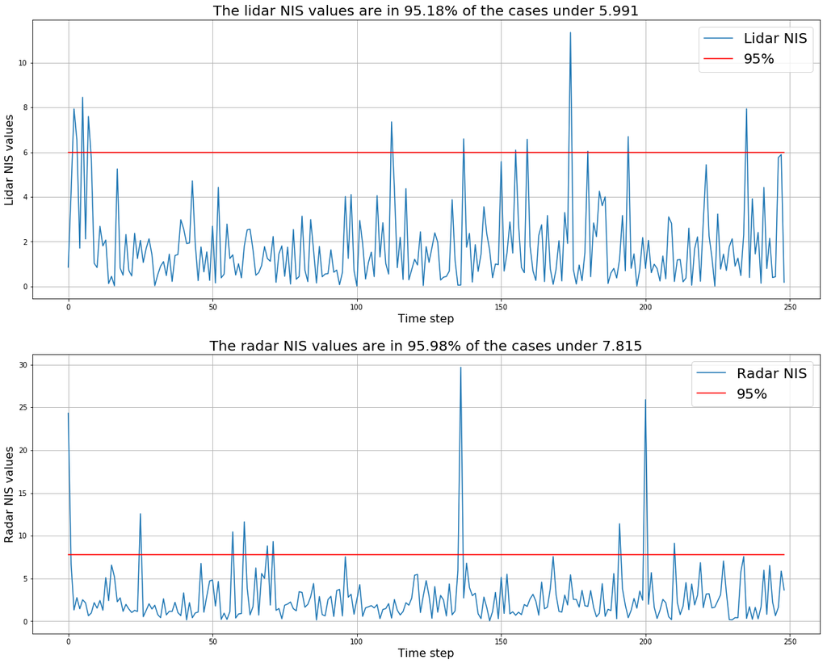

```python
plot_nis_values(3.0, 0.3)
```

Nah. :-/

```
./data/Lidar_NIS_values_2.0_0.2.txt -- read 249 lines from file
./data/Radar_NIS_values_2.0_0.2.txt -- read 249 lines from file
```

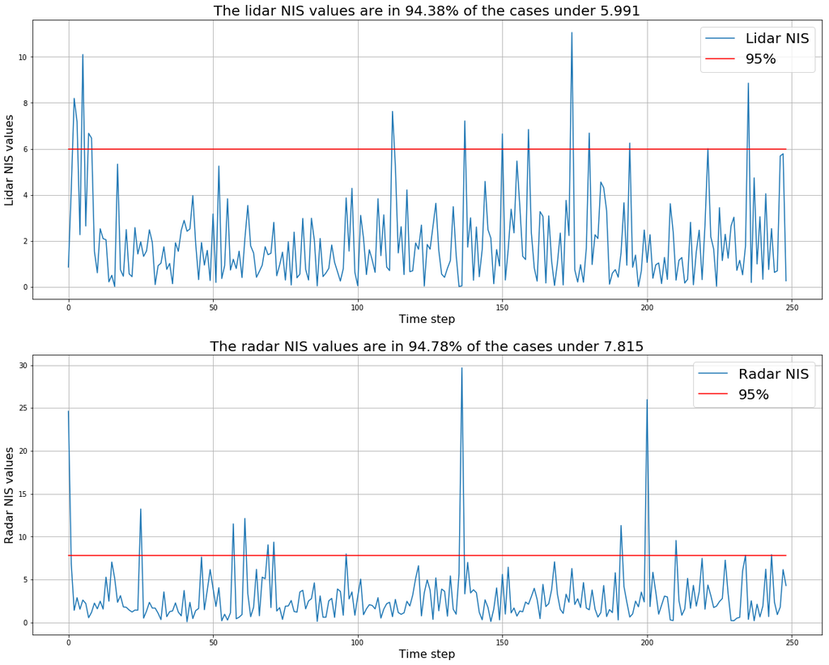

```python
plot_nis_values(2.0, 0.2)
```

Okay, let's go back towards 3.0 and 0.3...

```
./data/Lidar_NIS_values_2.5_0.25.txt -- read 249 lines from file
./data/Radar_NIS_values_2.5_0.25.txt -- read 498 lines from file
```

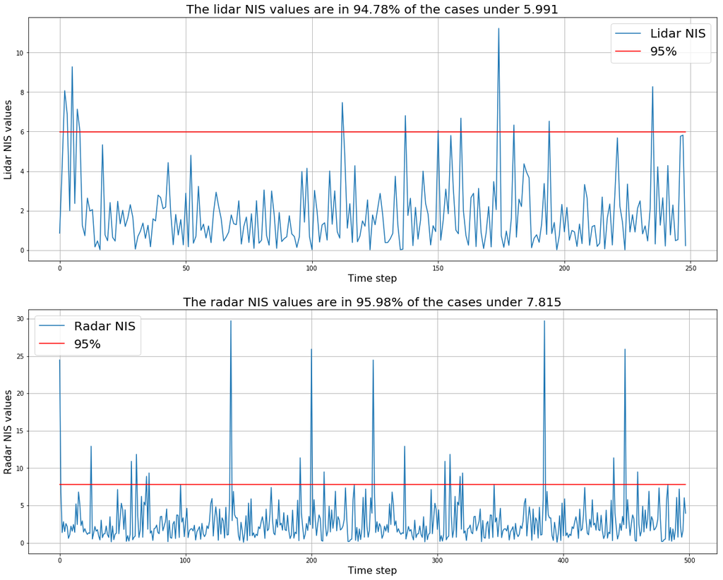

```python
plot_nis_values(2.5, 0.25)
```

```
./data/Lidar_NIS_values_2.0_0.25.txt -- read 249 lines from file
./data/Radar_NIS_values_2.0_0.25.txt -- read 249 lines from file
```

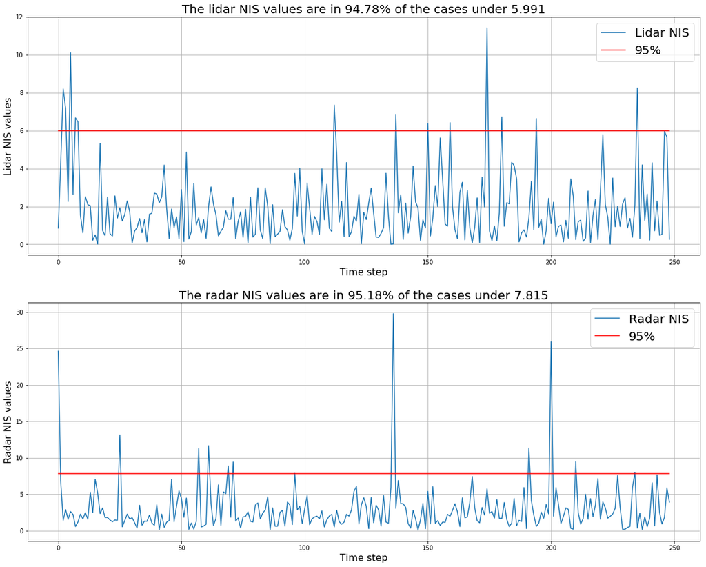

```python
#             0.8  0   0   0   0
#              0  0.8  0   0   0
# P_initial =  0   0  0.8  0   0
#              0   0   0  0.8  0
#              0   0   0   0  0.8

plot_nis_values(2.0, 0.25)
```

Looks quite okay. Let's try to adjust the initialization values to see whether that changes anything.

```
./data/Lidar_NIS_values_2.0_0.25_Pidentity.txt -- read 249 lines from file
./data/Radar_NIS_values_2.0_0.25_Pidentity.txt -- read 249 lines from file
```

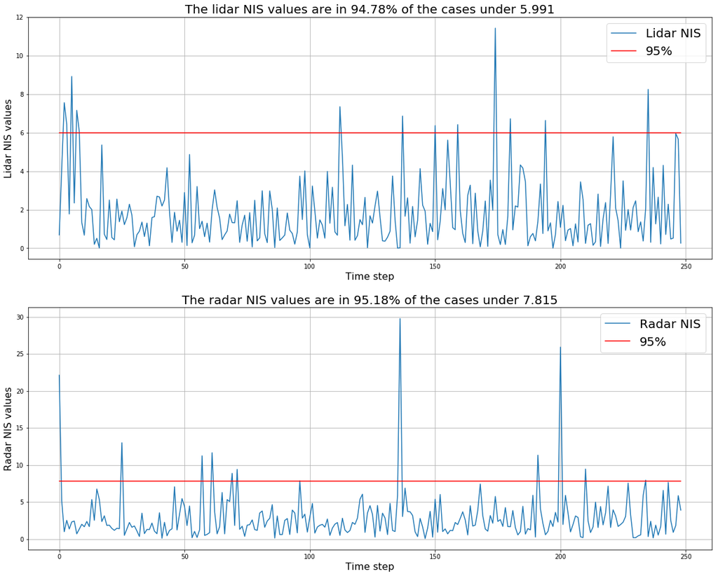

```python
#              1   0   0   0   0
#              0   1   0   0   0
# P_initial =  0   0   1   0   0
#              0   0   0   1   0
#              0   0   0   0   1

plot_nis_values(2.0, 0.25, file_suffix='_Pidentity')
```

Mm, not much.

```
./data/Lidar_NIS_values_2.0_0.25_P0.1.txt -- read 249 lines from file
./data/Radar_NIS_values_2.0_0.25_P0.1.txt -- read 249 lines from file
```

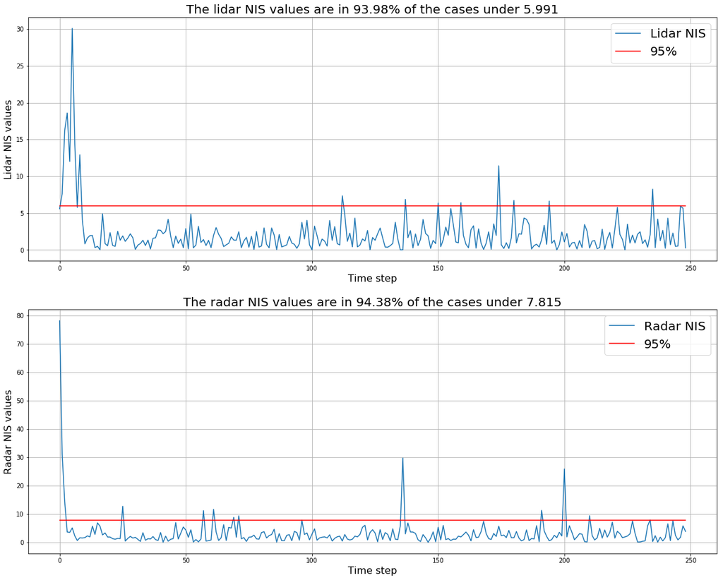

```python
#              0.1 0   0   0   0
#              0  0.1  0   0   0
# P_initial =  0   0  0.1  0   0
#              0   0   0  0.1  0
#              0   0   0   0  0.1

plot_nis_values(2.0, 0.25, file_suffix='_P0.1')
```

Bad idea. I'll stick to P filled with 0.8s diagonally, std_a = 2.0 and std_yawd ~ 0.25.